# AtivIdade 06

Pacotes utilizados neste RMD.

```r
library("rmdformats")
library("readxl")
library("dplyr")
```

```r
library("ggplot2")
```

# Exercício 1

Um estudo avaliou o efeito de dois medicamentos num grupo de pacientes com problemas cardíacos. Os pacientes foram aleatoriamente selecionados para receber um dos medicamentos. A idade e os níveis de colesterol (lipoproteínas de alta densidade, HDL) estão disponíveis na planilha.

## a) Verifique a suposição de normalidade da idade e dos níveis de colesterol destes pacientes.

**Resolução:** Primeiramente, vamos ler os dados:

```r
dados <- read_excel("06_Atividade_dados.xlsx", sheet="Exerc1")
head(dados)
```

```
## # A tibble: 6 × 3
##   Grupo Idade Colesterol
##   <chr> <dbl>      <dbl>
## 1 M1       25       144.
## 2 M1       65       138.
## 3 M1       61       140.
## 4 M1       71       155.
## 5 M1       57       155.
## 6 M1       88       175.
```

```r
attach(dados)
```

Para análisar a suposição de normalidade dos dados, precisamos separar os dados referentes ao medicamento M1 e ao medicamento M2. Iremos extrair estes dois subconjuntos.

```r
dados_M1 <- subset(dados, Grupo == "M1")
dados_M2 <- subset(dados, Grupo == "M2")
```

Antes de fazer a análise, podemos plotar os gráficos para visualizarmos suas distribuições.

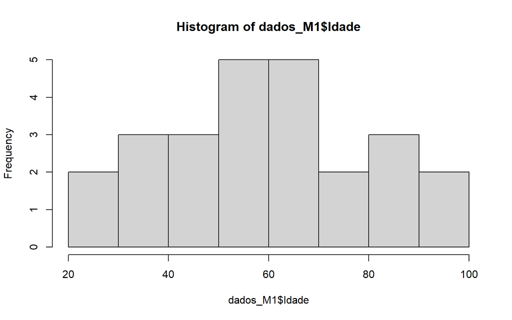

```r
hist(dados_M1$Idade)
```

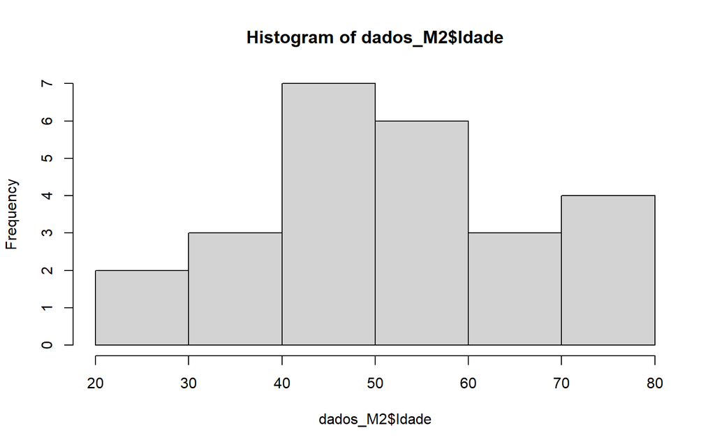

```r
hist(dados_M2$Idade)
```

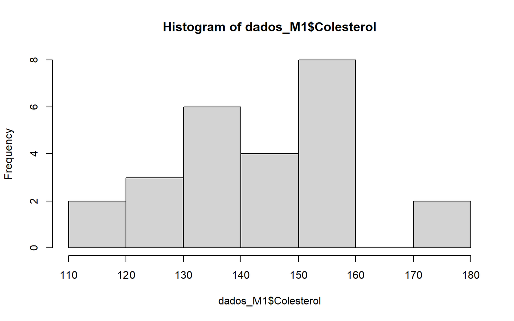

```r
hist(dados_M1$Colesterol)
```

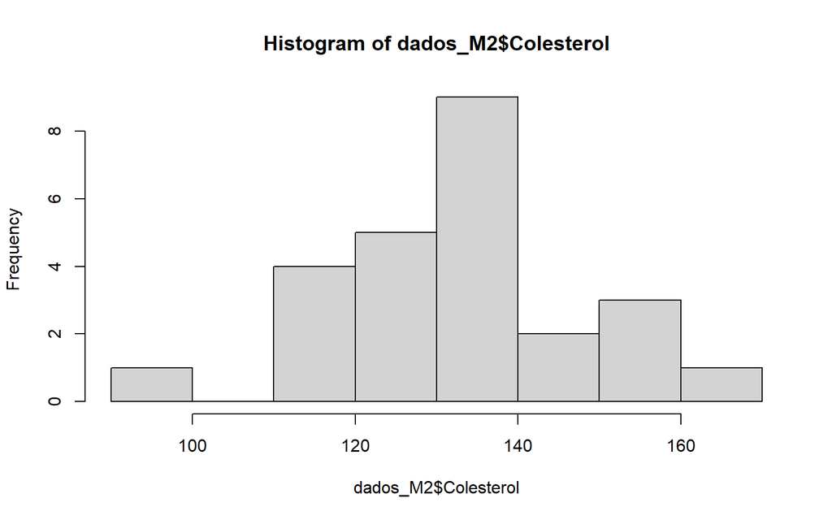

```r
hist(dados_M2$Colesterol)
```

Podemos aplicar nosso teste de hipóteses de normalidade sendo que as hipóteses são:

$H_0:$ A variável possui distribuição normal.

$H_1:$ A variável não possui distribuição normal.

Aplicando o teste de normalidade em cada variável:

```r
shapiro.test(dados_M1$Idade)
```

```
##
##  Shapiro-Wilk normality test
##
## data:  dados_M1$Idade
## W = 0.97676, p-value = 0.8142
```

```r
shapiro.test(dados_M2$Idade)
```

```
##
##  Shapiro-Wilk normality test
##
## data:  dados_M2$Idade
## W = 0.96009, p-value = 0.4163
```

```r
shapiro.test(dados_M1$Colesterol)
```

```
##
##  Shapiro-Wilk normality test
##
## data:  dados_M1$Colesterol
## W = 0.98071, p-value = 0.8988
```

```r
shapiro.test(dados_M2$Colesterol)
```

```
##
##  Shapiro-Wilk normality test
##
## data:  dados_M2$Colesterol
## W = 0.98097, p-value = 0.9036
```

Podemos ver que em todos os casos há um p-valor bem alto. Assim, considerando um nível de significância de 0.05, não rejeitamos a hipótese de normalidade de nenhum dos casos.

## b) Compare as variâncias da idade e do nível de colesterol dos pacientes que receberam os dois medicamentos, com nível de significância de 0,05.

**Resolução:** Com a hipótese de normalidade dos dados verificada, podemos prosseguir com um teste de hipóteses para a comparação de duas variâncias pela distribuição F. Neste caso, iremos comparar as variâncias da idade e do colesterol entre os dois grupos.

$H_0:$ As variâncias são iguais.

$H_1:$ As variâncias não são iguais.

Vamos analisar por primeiro em relação ao colesterol.

```r
var.test(Colesterol ~ Grupo)
```

```
##
##  F test to compare two variances
##
## data:  Colesterol by Grupo
## F = 0.99085, num df = 24, denom df = 24, p-value = 0.9822
## alternative hypothesis: true ratio of variances is not equal to 1
## 95 percent confidence interval:
##  0.4366368 2.2485133
## sample estimates:
## ratio of variances
##          0.9908499
```

No teste, temos que o p-valor foi de 0.9822, indicando que não rejeitamos a hipótese nula de que as variâncias são iguais.

Já no caso das idades:

```r
var.test(Idade ~ Grupo)
```

```
##
##  F test to compare two variances
##
## data:  Idade by Grupo
## F = 2.056, num df = 24, denom df = 24, p-value = 0.08381
## alternative hypothesis: true ratio of variances is not equal to 1
## 95 percent confidence interval:
##  0.9060086 4.6655995
## sample estimates:
## ratio of variances
##           2.055985
```

Obtemos um p-valor de 0.08381 que não é tão alto, mas já é maior que o nível de significância de 0.05, indicando que também não rejeitamos a hipótese nula de que as variâncias são iguais.

Portanto, podemos inferir que as variâncias da idade e colesterol são iguais em ambos os grupos.

## c) Há diferenã das médias da idade e do nível de colesterol dos pacientes entre os dois grupos? Utilize o nível de significância de 0,05. Construa os intervalos de confiança de 95% para a diferença de médias entre os grupos das duas variáveis.

**Resolução:** Novamente, como a hipótese de normalidade foi testada, podemos aplicar um teste de hipóteses entre médias pela distribuição t-student. Além disso, precisamos saber se as variâncias são iguais ou não para aplicarmos o teste.

$H_0:$ As variáveis possuem a mesma média (diferença das médias igual à zero).

$H_1:$ As variáveis possuem médias distintas (diferença das médias diferente de zero).

Primeiramente faremos a comparação do colesterol nos dois grupos.

```r
t.test(Colesterol~Grupo, var.equal = TRUE, alternative = "two.sided")
```

```
##
##  Two Sample t-test
##
## data:  Colesterol by Grupo
## t = 2.51, df = 48, p-value = 0.0155
## alternative hypothesis: true difference in means between group M1 and group M2 is not equal to 0
## 95 percent confidence interval:
##   2.245691 20.330309
## sample estimates:
## mean in group M1 mean in group M2
##          143.988          132.700
```

Obtemos um p-valor de 0.0155 que é abaixo do nível de significância de 0.05 indicando a rejeição da hipótese nula de médias iguais. Podemos inclusive notar que o intervalo de confiança de 95% da diferença entre as médias não inclui o valor 0, indicando que há pouca chance das médias serem iguais.

Assim, rejeitando a hipótese nula, inferimos que as médias de colesterol são diferentes entre os dois grupos.

Já nas idades:

```r
t.test(Idade~Grupo, var.equal = TRUE, alternative = "two.sided")
```

```
##
##  Two Sample t-test
##
## data:  Idade by Grupo
## t = 1.5186, df = 48, p-value = 0.1354
## alternative hypothesis: true difference in means between group M1 and group M2 is not equal to 0
## 95 percent confidence interval:
##  -2.501595 17.941595
## sample estimates:
## mean in group M1 mean in group M2
##            59.24            51.52
```

O p-valor de 0.1354 é maior que o nível de significância, indicando a não rejeição da hipótese nula de que as médias são iguais.

Portanto, podemos inferir que as médias das idades nos dois grupos são iguais, porém os níveis de colesterol são distintos.

## d) Interprete os resultados obtidos.

**Resolução:** Podemos dizer primeiramente que houve uma boa amostragem e delineamento de experimento realizado, no qual pudemos obter variáveis que atendessem algumas suposições estatísticas para nossas análises, tanto da normalidade, quanto da variância das variáveis. Além disso, a média das idades é igual nos dois grupos indicando qualidade da pesquisa também, pois uma média diferente poderia ocasionar num viés para demais análises, como na do colesterol.

Por fim, chegamos na conclusão de que há diferença na média de colesterol entre cada grupo, indicando que há relação (não necessariamente causal) entre o medicamento e o nível de colesterol.

E observando os valores das médias:

```r
mean(dados_M1$Colesterol)
```

```
## [1] 143.988
```

```r
mean(dados_M2$Colesterol)
```

```
## [1] 132.7
```

Podemos dizer que o grupo com o medicamento M1 teve uma média maior de colesterol do que o com o medicamento M2, embora as variâncias sejam as mesmas.

# Exercício 2

Um levantamento avaliou a qualidade do serviço prestado por duas empresas de transporte municipal por parte dos usuários. O questionário perguntou a opinião sobre o serviço e as possíveis respostas foram: Péssimo, Ruim, Regular, Bom e Ótimo. Os dados encontram-se na planilha. Há diferença de opinião dos usuários entre as duas empresas? Use o nível de significância de 0,05.

**Resolução:**

```r
dados2 <- read_excel("06_Atividade_dados.xlsx", sheet="Exerc2")
head(dados2)
```

```
## # A tibble: 6 × 2
##   Empresa   Opinião
##   <chr>     <chr>
## 1 Empresa A Péssimo
## 2 Empresa A Regular
## 3 Empresa A Bom
## 4 Empresa A Regular
## 5 Empresa A Regular
## 6 Empresa A Bom
```

```r
attach(dados2)
```

Para fazer a análise, precisaremos atribuir valores para definir a ordem da variável categórica ordinal Opinião. Para isso, podemos usar o pacote dplyr.

```r
dados2 <- dados2 %>%
  mutate(
    Opinião2 = case_when(
      Opinião == "Péssimo" ~ 1,
      Opinião == "Ruim" ~ 2,
      Opinião == "Regular" ~ 3,
      Opinião == "Bom" ~ 4,
      Opinião == "Ótimo" ~ 5
    )
  )

attach(dados2)
```

Neste caso, como temos variáveis categóricas, utilizaremos a mediana para o teste de hipóteses.

$H_0:$ A mediana das opiniões são iguais entre as empresas.

$H_1:$ A mediana das opiniões são diferentes.

Podemos agora fazer um teste de normalidade para cada caso. Novamente, a hipótese nula é de que a distribuição é normal.

```r
tapply(Opinião2,Empresa,shapiro.test)
```

```
## $`Empresa A`
##
##  Shapiro-Wilk normality test
##
## data:  X[[i]]
## W = 0.87623, p-value < 2.2e-16
##
##
## $`Empresa B`
##
##  Shapiro-Wilk normality test
##
## data:  X[[i]]
## W = 0.77738, p-value < 2.2e-16
```

Em ambos os casos o p-valor é bem pequeno, ou seja, rejeitamos a hipótese de normalidade nas distribuições das opiniões da empresa A e da empresa B.

Por isso, precisaremos utilizar um teste de hipóteses que não dependa da variável ter distribuição normal, como o teste wilcox.

Aplicando o teste:

```r
wilcox.test(Opinião2~Empresa,alternative = "two.sided")
```

```
##
##  Wilcoxon rank sum test with continuity correction
##
## data:  Opinião2 by Empresa
## W = 249248, p-value = 4.045e-09
## alternative hypothesis: true location shift is not equal to 0
```

Como o p-valor é extremamente pequeno, e consequentemente menor que o nível de significância de 0.05, rejeitamos a hipótese nula de que as medianas entre as empresas são iguais.